# Programming Data Science Report

## 2.2 Visualisation

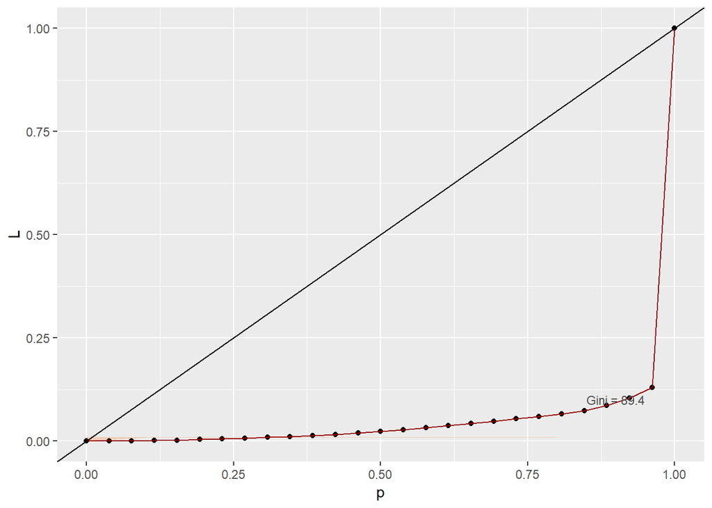

```r
library(ineq)
brand_vs_clicks <- click_df %>%
  select(BrandName,Session_Visit_Count,Session_ID) %>%
  group_by(BrandName) %>%
  summarise(clicks=sum(Session_Visit_Count))
totalclicks <- sum(brand_vs_clicks$clicks)
brand_vs_clicks <- brand_vs_clicks %>%
  select(BrandName,clicks) %>%
  group_by(BrandName) %>%
  summarise(clicks = clicks, click_pro = clicks/totalclicks)
G <- rep(10,10)
G_kum <- c(0,cumsum(G/100))
G1 <- brand_vs_clicks$click_pro
G1_kum <- c(0,cumsum(brand_vs_clicks$click_pro/100))
D1 <- Lc(G1, n = rep(1,length(G1)), plot = FALSE)
p <- D1[1]
L <- D1[2]
D1_df <- data.frame(p,L)
xx <- c(G_kum,rev(G_kum))
yy <- c(G1_kum,rev(G_kum))
koordinaten <- as.data.frame(xx)
koordinaten$yy <- yy[1:22]
gini <- round(ineq(G1) * 100, digits = 1)
p1 <- ggplot(data=D1_df) +
  geom_point(aes(x=p, y=L)) +
  geom_line(aes(x=p, y=L), stat = "identity", color="#990000") +
  geom_polygon(data = koordinaten, aes(x = xx, y = yy), fill = rgb(255,100,0,55,maxColorValue=255)) +
  annotate("text", x = 0.9, y = 0.1, label = paste("Gini =", gini), size=3, colour="gray30") +
  geom_abline()
p1
```

```r
#ggplot(brand_vs_clicks)+
#  geom_point(mapping = aes(x=BrandName,y=click_pro))
```

## 2.3 Summary tables

### 2.3.1 Clickstream tables

|  | Top1 | Top2 | Top3 | Top4 | Top5 |
| --- | --- | --- | --- | --- | --- |
| Referrer | www.gazelle.com | www.fashionmall.com | www.asianavenue.com | www.goto.com | www.AsianAvenue.com |
| Number_of_Referres | 93730 | 6533 | 2218 | 938 | 688 |
| Product | Cellulite Trimming Gel | Body Lotion - Oceanic Minerals | Kit-Firming Cream/Slimming Cream/Shorts | Body Silk | Herbal Foot Balm |
| Clicks_on_Product | 321 | 270 | 254 | 238 | 228 |
| Top_Click_Hours | 2 | 10 | 9 | 11 | 7 |
| Clicks_per_Hour | 13614 | 9777 | 9222 | 9151 | 8902 |
| Top_Click_Days | Saturday | Thursday | Sunday | Tuesday | Wednesday |
| Clicks_per_Day | 27388 | 25311 | 24605 | 22283 | 21896 |

In the `click_df` we united the first clickstream dataset and the secound clickstream dataset. Together the `click_df` contains 164364 click observations. We identifyed the top five from the `click_df` which are show above.

| summary_stats | max | mean | median | min | sd |
| --- | --- | --- | --- | --- | --- |
| Request_count | 1842.000 | 3.250999 | 1 | 1 | 17.8620117 |
| Session_duration_mins | 2861.083 | 10.835476 | 0 | 0 | 86.7627186 |
| Visited_assortments | 4.000 | 1.270323 | 1 | 1 | 0.4837795 |
| Visited_products | 154.000 | 1.321453 | 1 | 1 | 1.9212895 |

From the `click_df` dataset we extractet the `ave_Session_df`dataset. This dataset contains 50558 session observations. The tabel above summarizes the average session.

### 2.3.2 Order tables

|  | Top1 | Top2 | Top3 | Top4 | Top5 |
| --- | --- | --- | --- | --- | --- |
| Product_ID | 12883 | 10877 | 12327 | 12567 | 12675 |
| Orders_per_Product_ID | 142 | 120 | 119 | 105 | 94 |
| Product_Name | Cellulite Trimming Gel | Leg Therapy Cream | Toe Separators | Power Toenail Clipper | Sole Survivor Foot Kit |
| Orders_per_Product_Name | 9 | 9 | 7 | 7 | 7 |
| Customer_ID | 30208 | 2240 | 22742 | 538 | 25004 |
| Orders_per_Customer | 30 | 28 | 22 | 19 | 18 |
| Customer__ID | 29244 | 3778 | 28144 | 2240 | 30208 |
| Purchased_Products_per_Customer | 53 | 40 | 33 | 32 | 30 |
| Brand | AME | Silk Reflections | ELT | HOSO | DAN |
| Orders_per_Brand | 822 | 485 | 399 | 361 | 270 |
| Top_Sale_Hours | 16 | 17 | 19 | 14 | 10 |
| Orders_per_Hours | 231 | 225 | 225 | 223 | 214 |
| Top_Sale_Days | Wednesday | Tuesday | Thursday | Friday | Saturday |
| Orders_per_Day | 934 | 614 | 602 | 571 | 292 |

| summary_Return | max | mean | median | min | sd |
| --- | --- | --- | --- | --- | --- |
| Return_Quantity | 3.00 | 1.5714286 | 1 | 1.00 | 0.7867958 |
| Returned_Products | 2.00 | 1.1428571 | 1 | 1.00 | 0.3779645 |
| Used_Promotions | 1.00 | 0.7142857 | 1 | 0.00 | 0.4879500 |
| Discount_Amount | 10.00 | 7.1428571 | 10 | 0.00 | 4.8795004 |
| Discount_from_Sale_Price | 2.12 | 0.3028571 | 0 | 0.00 | 0.8012847 |
| Return_Amount | 44.50 | 23.0514286 | 30 | 3.95 | 16.6189404 |

The table “Summary_Return” is based on 7 return observations. We extracted these return from the order dataset.

| summary_Order | max | mean | median | min | sd |
| --- | --- | --- | --- | --- | --- |
| Order_Quantity | 53.00 | 2.3678460 | 2.00 | 1.0 | 2.7269390 |
| Purchased_Products | 9.00 | 1.3949011 | 1.00 | 1.0 | 0.8280827 |
| Used_Promotions | 1.00 | 0.8397503 | 1.00 | 0.0 | 0.3669330 |
| Discount_Amount | 50.00 | 8.6569823 | 10.00 | 0.0 | 7.3041332 |
| Discount_from_Sale_Price | 37.34 | 0.2050780 | 0.00 | 0.0 | 1.7156709 |
| Order_Amount | 562.35 | 14.0066441 | 5.95 | -0.7 | 26.3904424 |
| Creditcard_Payment_Amount | 562.35 | 21.4663424 | 14.95 | 0.0 | 27.0717254 |

The table “Summary_Order” is based on 1922 order observations. We extracted these orders from the order dataset.The negative minimum in the row “Order Amount” looks suspicious. Research in the data revealed that the orders: order-Id 12314 and order-Id 10930 used a special combination of products and the promotion code “FRIEND” to generate a negative order amount. However, the credit card payment amount indicates that the coups didn’t succeed. Also the datasets cannot tell if the negative Order Amount were create willingly or through accident.

The table below showes the average ordering customer.

```r
buffer <- order_df %>%
  select(Customer_ID,
         Age,Year_of_Birth,Gender,Estimated_Income_Code,Marital_Status,Presence_Of_Children,City,US_State,Country) %>%
  group_by(Customer_ID) %>%
  summarise_all(funs(last(.)))

buffer$Age <- 2019 -buffer$Year_of_Birth


#age

buffer1 <- buffer %>%
  select(Age)%>%
  group_by(Age)%>%
  summarise(numberof = n())

buffer1 <- filter(buffer1,!is.na(Age))

buffer1 <- buffer1[order(-buffer1$numberof),]

ave_customer <- buffer1[1:1,1:1]

# gender
buffer1 <- buffer %>%
  select(Gender)%>%
  group_by(Gender)%>%
  summarise(numberof = n())

buffer1 <- filter(buffer1,!is.na(Gender))

buffer1 <- buffer1[order(-buffer1$numberof),]

ave_customer[1:1,2:2] <- buffer1[1:1,1:1]

# relation status

buffer1 <- buffer %>%
  select(Marital_Status)%>%
  group_by(Marital_Status)%>%
  summarise(numberof = n())

buffer1 <- filter(buffer1,!is.na(Marital_Status))

buffer1 <- buffer1[order(-buffer1$numberof),]

ave_customer[1:1,3:3] <- buffer1[1:1,1:1]

# children

buffer1 <- buffer %>%
  select(Presence_Of_Children)%>%
  group_by(Presence_Of_Children)%>%
  summarise(numberof = n())

buffer1 <- filter(buffer1,!is.na(Presence_Of_Children))

buffer1 <- buffer1[order(-buffer1$numberof),]

ave_customer[1:1,4:4] <- buffer1[1:1,1:1]

# Estimated Income

buffer1 <- buffer %>%
  select(Estimated_Income_Code)%>%
  group_by(Estimated_Income_Code)%>%
  summarise(numberof = n())

buffer1 <- filter(buffer1,!is.na(Estimated_Income_Code))

buffer1 <- buffer1[order(-buffer1$numberof),]

ave_customer[1:1,5:5] <- buffer1[1:1,1:1]


# City

buffer1 <- buffer %>%
  select(City)%>%
  group_by(City)%>%
  summarise(numberof = n())

buffer1 <- filter(buffer1,!is.na(City))

buffer1 <- buffer1[order(-buffer1$numberof),]

ave_customer[1:1,6:6] <- buffer1[1:1,1:1]


# State

buffer1 <- buffer %>%
  select(US_State)%>%
  group_by(US_State)%>%
  summarise(numberof = n())

buffer1 <- filter(buffer1,!is.na(US_State))

buffer1 <- buffer1[order(-buffer1$numberof),]

ave_customer[1:1,7:7] <- buffer1[2:2,1:1]

ave_customer <- t(ave_customer)


kable(ave_customer)
```

| Age | 49 |
| --- | --- |
| Gender | Female |
| Marital_Status | Married |
| Presence_Of_Children | FALSE |
| Estimated_Income_Code | $50000-$74999 |
| City | New York |
| US_State | NY |

## 2.4 Comparison of groups

### 2.4.1 Predict Moretimebuyer

```r
buffer<- order_df %>%
  select(Order_Customer_ID,Order_ID,Order_Line_ID,
         Order_Line_Quantity,Product_ID,Order_Date,Order_Promotion_Code,
         Order_Discount_Amount,Order_Line_Unit_List_Price,Order_Line_Unit_Sale_Price,Order_Amount,
         Order_Customer_ID,Product,Order_Credit_Card_Payment_Amount,BrandName,Order_Hour_of_Day,Order_Day_of_Week,
         Order_Credit_Card_Brand,Gender) %>%
  group_by(Order_Customer_ID,Order_ID,Order_Line_ID)


buffer_order <- order_df %>%
  select(Order_Customer_ID,Order_ID)%>%
  group_by(Order_Customer_ID) %>%
  summarise(Orders = length(unique(Order_ID)))


buffer <- merge(buffer,buffer_order,by = "Order_Customer_ID")


buffer <- buffer %>%
  select(Order_Customer_ID,Order_ID,Order_Line_ID,Order_Line_Quantity,Product_ID,Order_Date,Order_Promotion_Code,Order_Discount_Amount,Order_Line_Unit_List_Price,
         Order_Line_Unit_Sale_Price,Order_Amount,Product,Order_Credit_Card_Payment_Amount,BrandName,Order_Hour_of_Day,Order_Day_of_Week,
         Order_Credit_Card_Brand,Gender,Orders)%>%
  group_by(Order_ID)%>%
  summarise(Order_Line_Quantity = first(Order_Line_Quantity),
            Product_ID = first(Product_ID),
            Order_Date = first(Order_Date),
            Order_Promotion_Code = first(Order_Promotion_Code),
            Order_Discount_Amount = first(Order_Discount_Amount),
            Order_Line_Unit_List_Price = first(Order_Line_Unit_List_Price),
            Order_Line_Unit_Sale_Price = first(Order_Line_Unit_Sale_Price),
            Order_Amount = first(Order_Amount),
            Product = first(Product),
            Order_Credit_Card_Payment_Amount = first(Order_Credit_Card_Payment_Amount),
            BrandName = first(BrandName),
            Order_Hour_of_Day = first(Order_Hour_of_Day),
            Order_Day_of_Week = first(Order_Day_of_Week),
            Order_Credit_Card_Brand = first(Order_Credit_Card_Brand),
            Gender= first(Gender),
            Orders = first(Orders))

buffer$moretimebuyer <- c(TRUE)

buffer$moretimebuyer <- replace(buffer$moretimebuyer,buffer$Orders< 2,FALSE)

buffer <-buffer[order(-buffer$moretimebuyer),]


buffer <- buffer %>%
  select(Order_Line_Quantity,Product_ID,Order_Date,Order_Promotion_Code,
         Order_Discount_Amount,Order_Line_Unit_List_Price,Order_Line_Unit_Sale_Price,Order_Amount,
         Product,Order_Credit_Card_Payment_Amount,BrandName,Order_Hour_of_Day,Order_Day_of_Week,
         Order_Credit_Card_Brand,Gender,moretimebuyer)


#split T and F and randomize

buffer3 <- filter(buffer,moretimebuyer==TRUE)

buffer3 <- buffer3[sample(nrow(buffer3)),]

buffer4 <- filter(buffer,moretimebuyer==FALSE)

buffer4 <- buffer4[sample(nrow(buffer4)),]

train <- buffer3[1:78,]
train <- rbind(train,buffer4[1:100,])

test <- buffer3[78:156,]
test <- rbind(test,buffer4[100:200,])



library(rpart)
library(rpart.utils)
library(rpart.plot)
fit <- rpart(moretimebuyer~
               Order_Credit_Card_Payment_Amount+Order_Hour_of_Day+Order_Day_of_Week+
               Order_Credit_Card_Brand+
               Gender
             ,data = train,method = "class",
             control = rpart.control(xval = 10))

rpart.rules(fit)
```

```
##  moretimebuyer
##           0.11 when Order_Credit_Card_Payment_Amount <  19       & Order_Day_of_Week is             Monday or Sunday or Tuesday or Wednesday & Order_Hour_of_Day is  9 to 11
##           0.14 when Order_Credit_Card_Payment_Amount >=       21 & Order_Day_of_Week is Friday or Monday or Saturday or Tuesday or Wednesday & Order_Hour_of_Day >=       18
##           0.17 when Order_Credit_Card_Payment_Amount <  19       & Order_Day_of_Week is                       Friday or Saturday or Thursday                                 & Order_Credit_Card_Brand is MC or VISA
##           0.27 when Order_Credit_Card_Payment_Amount <  19       & Order_Day_of_Week is             Monday or Sunday or Tuesday or Wednesday & Order_Hour_of_Day >=       19
##           0.28 when Order_Credit_Card_Payment_Amount <  19       & Order_Day_of_Week is             Monday or Sunday or Tuesday or Wednesday & Order_Hour_of_Day is 13 to 17
##           0.35 when Order_Credit_Card_Payment_Amount >=       21 & Order_Day_of_Week is Friday or Monday or Saturday or Tuesday or Wednesday & Order_Hour_of_Day <  13
##           0.56 when Order_Credit_Card_Payment_Amount <  19       & Order_Day_of_Week is                       Friday or Saturday or Thursday                                 & Order_Credit_Card_Brand is       AMEX
##           0.71 when Order_Credit_Card_Payment_Amount <  19       & Order_Day_of_Week is             Monday or Sunday or Tuesday or Wednesday & Order_Hour_of_Day is 11 to 13
##           0.78 when Order_Credit_Card_Payment_Amount <  19       & Order_Day_of_Week is             Monday or Sunday or Tuesday or Wednesday & Order_Hour_of_Day is 17 to 19
##           0.78 when Order_Credit_Card_Payment_Amount >=       21 & Order_Day_of_Week is Friday or Monday or Saturday or Tuesday or Wednesday & Order_Hour_of_Day is 13 to 18
##           0.80 when Order_Credit_Card_Payment_Amount <  19       & Order_Day_of_Week is             Monday or Sunday or Tuesday or Wednesday & Order_Hour_of_Day <   9
##           0.82 when Order_Credit_Card_Payment_Amount >=       21 & Order_Day_of_Week is                                   Sunday or Thursday
##           1.00 when Order_Credit_Card_Payment_Amount is 19 to 21
```

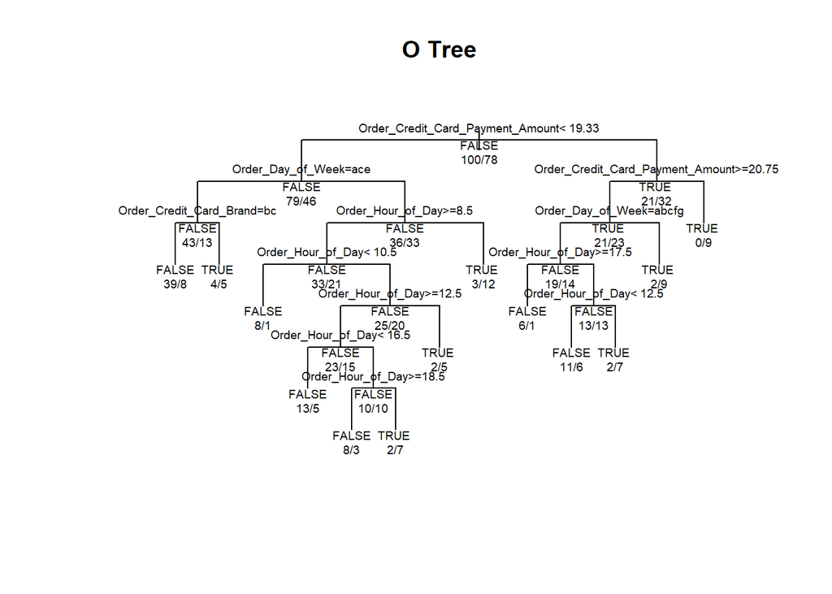

```r
plot(fit, uniform = TRUE,margin = 0.1,main = "O Tree")
text(fit, use.n = TRUE,all = TRUE,cex=.6)
```

```r
prediction <- predict(fit,test,type = "class")
table(prediction,test$moretimebuyer)
```

```
##
## prediction FALSE TRUE
##      FALSE    70   39
##      TRUE     31   40
```

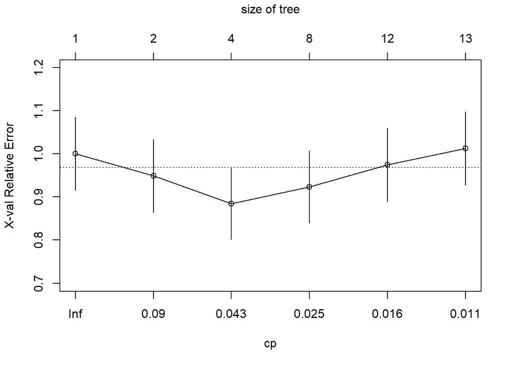

```r
plotcp(fit)
```

```r
kable(fit$cptable)
```

| CP | nsplit | rel error | xerror | xstd |
| --- | --- | --- | --- | --- |
| 0.1410256 | 0 | 1.0000000 | 1.0000000 | 0.0848678 |
| 0.0576923 | 1 | 0.8589744 | 0.9487179 | 0.0843001 |
| 0.0320513 | 3 | 0.7435897 | 0.8846154 | 0.0833361 |
| 0.0192308 | 7 | 0.6153846 | 0.9230769 | 0.0839488 |
| 0.0128205 | 11 | 0.5128205 | 0.9743590 | 0.0846062 |
| 0.0100000 | 12 | 0.5000000 | 1.0128205 | 0.0849819 |

```r
# cp 0.06 best performace for minimal False classified as True

# cp 0.04 to 0.56 best performace for minimal True classified as False

fit.pruned <- prune(fit,cp = fit$cptable[which.min(fit$cptable[,"xerror"]),"CP"] )

rpart.rules(fit.pruned)
```

```
##  moretimebuyer
##           0.23 when Order_Credit_Card_Payment_Amount <  19 & Order_Day_of_Week is           Friday or Saturday or Thursday
##           0.39 when Order_Credit_Card_Payment_Amount <  19 & Order_Day_of_Week is Monday or Sunday or Tuesday or Wednesday & Order_Hour_of_Day >= 9
##           0.60 when Order_Credit_Card_Payment_Amount >= 19
##           0.80 when Order_Credit_Card_Payment_Amount <  19 & Order_Day_of_Week is Monday or Sunday or Tuesday or Wednesday & Order_Hour_of_Day <  9
```

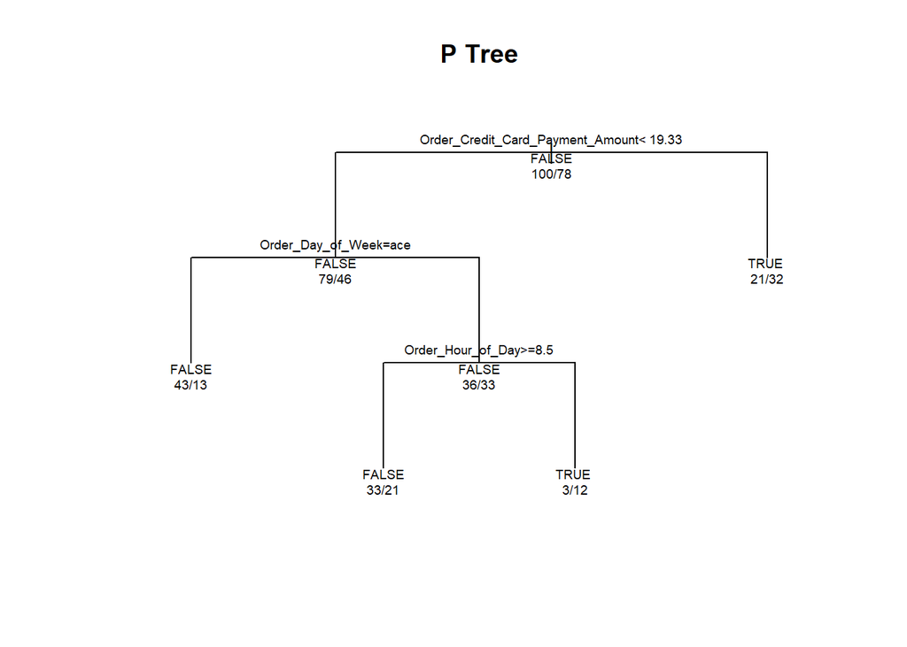

```r
plot(fit.pruned, uniform = TRUE,margin = 0.1, main= "P Tree")
text(fit.pruned, use.n = TRUE,all = TRUE,cex=.6)
```

```r
prediction_p <- predict(fit.pruned,test,type = "class")
table(prediction_p,test$moretimebuyer)
```

```
##
## prediction_p FALSE TRUE
##        FALSE    63   37
##        TRUE     38   42
```

## 2.5 Experiment: Recommender Systems

For the websites recommender systems, there are different options. In an experiment, three different recommender systems were tested. First a random recommendation system as baseline comparison for the experiment, second a ranking based recommender system and third a profit oriented recommender system. The data consisted of 146 observations for the profit oriented system, 149 for the random one and 154 observations for the ranking based system.

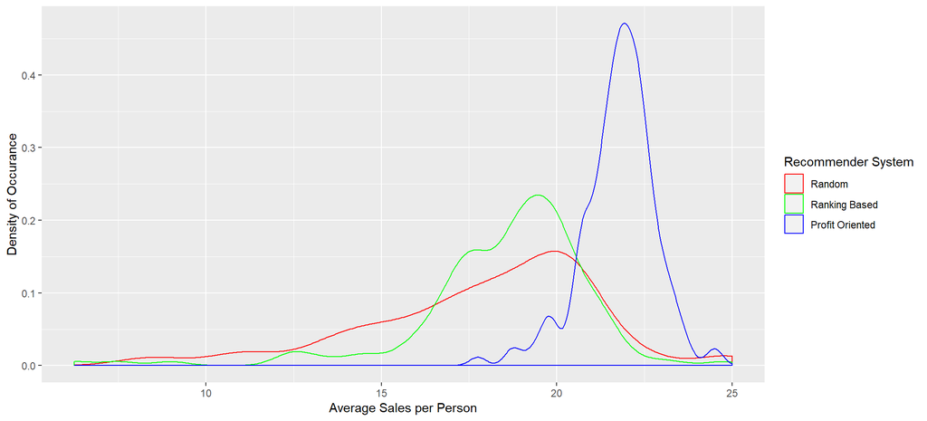

```r
knitr::knit_exit()
library(rpart)
library(caTools)
library(rpart.plot)
require(tree)
library(party)
library(class)
library(rpart.utils)
library(e1071)
library(caret)
# Columns for session click prediction
# RequestReferrer / RequestTemplate , RequestDayOfWeek, RequestHourOfDay, Session User AGent, , SessionFirstRequestHourOfDay, SessionFirstDayOfWeek
temp <- filter(ave_Session_df, Request_count > 1)
temp <- subset(temp, select=c(Session_duration_mins,Session_day, Session_hour, Referrer, LeadsToBuy))

temp$Session_day <- factor(temp$Session_day, levels = c("Monday", "Tuesday", "Wednesday",
                          "Thursday", "Friday", "Saturday", "Sunday"),
            ordered = TRUE)
temp$Session_day <- as.integer(temp$Session_day)
temp$Referrer <- as.integer(as.factor(temp$Referrer))
```

Getting to *data manipulation*, a few things within the datasets had to be fixed.

1. Empty cells had several different values, e.g. `?` or `NULL`. All of these were changed to R-modifiable `NA` values.
2. Empty rows/observations and columns/features were dropped.
3. Duplicate features were dropped as well. This affected 0 columns in the order dataset and 0 columns in the clickstream dataset.
4. Column names included spaces that became problematic in later analysis. They were simply replaced by underscores.
5. All semicolons within cells were simply erased.
6. Besides, backslashes within cells were erased as well.

In order to be able to work and process faster, the cleaned and manipulated datasets were saved to files in R data format (RDAs). If cleaning is done once, all steps above can be skipped and it can directly be headed forward to the data insights and analysis.

On a first look, the data provides the following information:

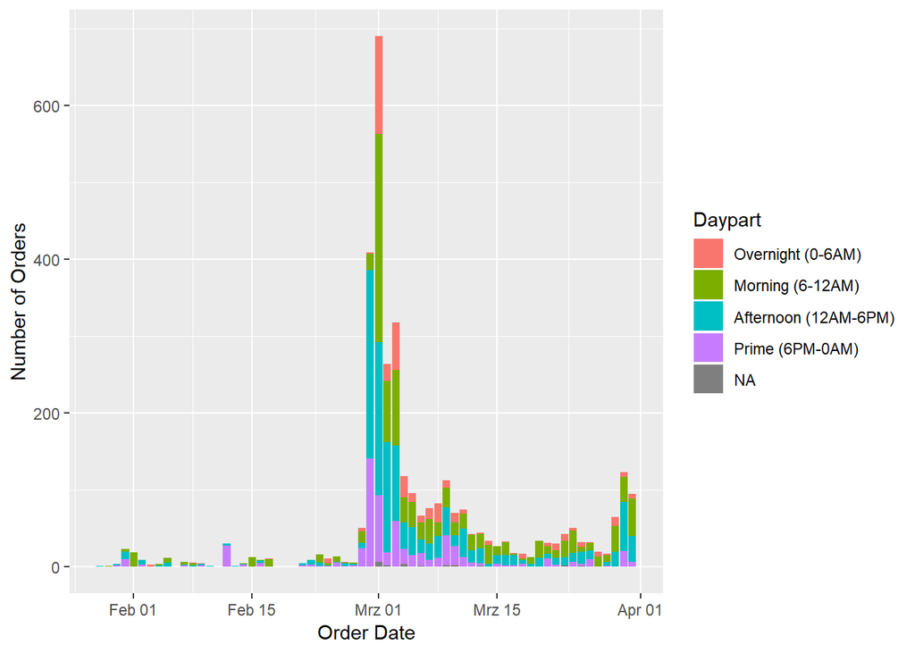

What can be observed is that most of the orders were placed at March 1, namely 690. 1946 or 56.2% of all orders have been placed in the week of February 28.  
Further, interestingly the amount of orders of March 1 placed overnight or in the morning is quite high. It could be assumed that there was a special time limited offer in the early hours of March 1.  
Overall, only 323 customers specified their gender as “male” and 1584 as “female”. However, men seem to spend more money on average as the boxplot indicates.

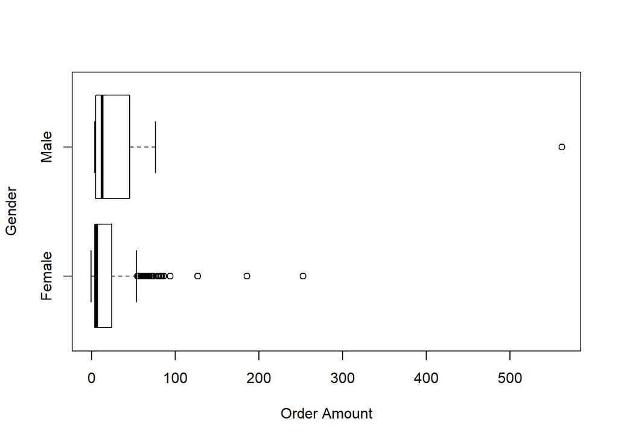